# Logistic Regression

Eli Clapper

27-12-2021

In Logistic regression it does not make sense to draw a straight line through the relationship between X and Y, because Y is either 1 or 0. Drawing a straight line would make us predict continuous values on Y, even though Y is binary.

```r
set.seed(6164900)
nk <- 200
Y <- rep(0:1, each = nk) #simulate from binomial with probability 0.5
X1 <- c(rnorm(nk, -0.5, 1), rnorm(nk, 0.5, 1))
```

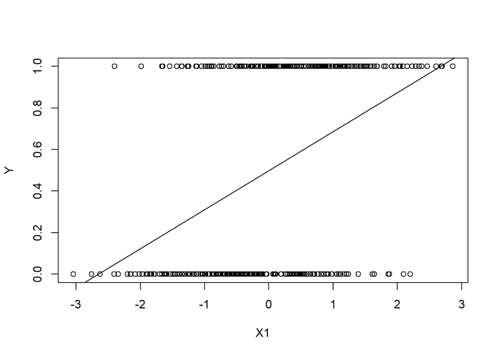

```r
source("../Created_Functions.R")
ols <- OLS(Y, X1) #retrieved from Linear_model.Rmd
plot(X1,Y) # someone with score 0 on X
b0 <- ols$estimates[1,1]
b1 <- ols$estimates[2,1]
abline(b0, b1)
```

```r
# fit <- glm(Y~X, family = 'binomial')
# predval <- ifelse(fit$fitted.values >= 0.5, 1,0)
# mean(Y == predval)
# summary(fit)
```

Plugging in OLS estimates gives us a line through the data that would predict very badly, because the outcome is binary and not continuous. So, what essentially is done in logistic regression, is we do not model Y in its binary form, but we model Y in such a way that it can be written as a linear function of X. Such a linear function is called a ‘link function’.

One of those functions is the ‘logit’ functions. To obtain this, we firstly write Y not as binary, but as a continuous probability: $P(Y = 1|X)$, denoted as p(x). This makes Y continuous. This probability can be obtained by taking the sigmoid function of x:
$$\begin{align}
p(x) &= \frac{e^{\beta_0 + \beta X}}{1+e^{\beta_0 + \beta X}} \\ \\
&= \frac{1}{1+e^{-(\beta_0 + \beta X)}}
\end{align}$$
The output is within the range [0,1]. We can code such a function to see what it looks like and how it would predict Y. For the values of $\beta_0$ and $\beta$ we for now put in estimates that are obtained from the `glm()` function because we already know those will fit well.

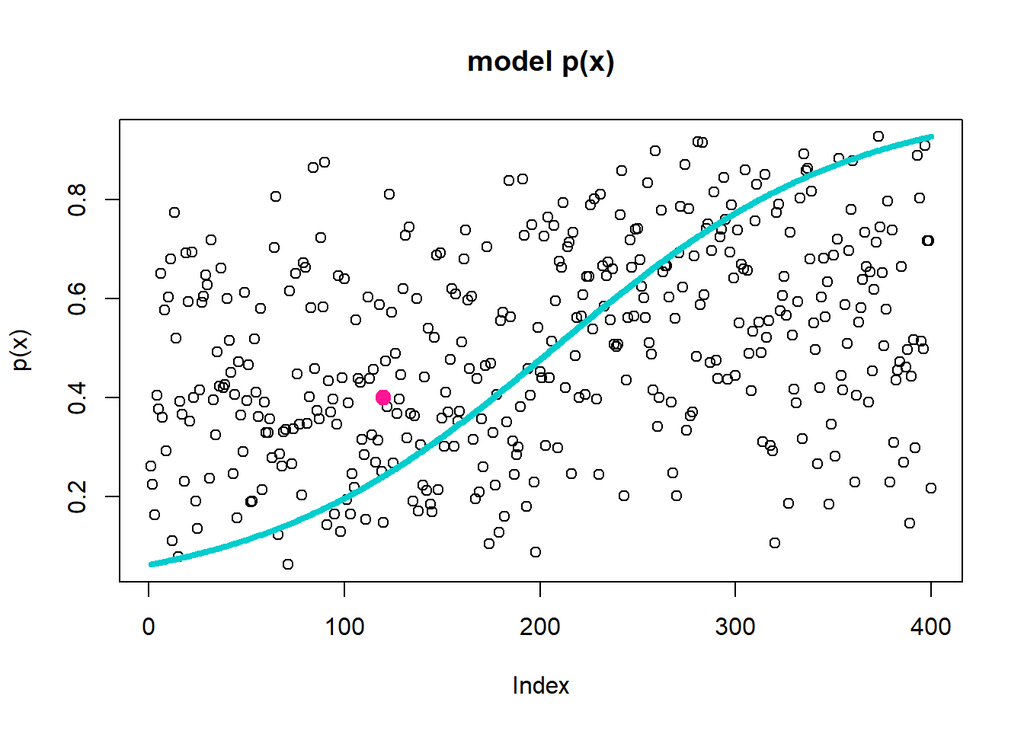

```r
px <- function(x, b0, beta){
  S <- exp(b0+beta*x)
  return(S/(1+S))
}
fitglm <- glm(Y~X1, family = "binomial")
b0 <- fitglm$coefficients[1]
beta <- fitglm$coefficients[2]

plot(px(X1, b0, beta), ylab = 'p(x)', main = "model p(x)" )
lines(px(seq(min(X1), max(X1), length.out = length(X1)), b0, beta), col = 'cyan3', lwd = 4)
points(120, 0.4, col = "deeppink", pch = 19, cex = 1.4)
```

Note that the component that $e$ is raised to in equation 1 is a linear function. So usually, to make the model more understandable in regards to X, the equation is rewritten as a form of $\beta_0 + \beta X$

And so we rewrite the model like so:
$$\frac{p(x)}{1-p(x)} = e^{\beta_0 + \beta_1X}$$

and even further to finally obtain the logit function:
$$\ln(\frac{p(x)}{1-p(x)}) = \beta_0 + \beta_1X$$

And so we rewrote Y as a linear function of X by first modeling the probability of Y = 1 given X and than taking the log odds of this probability. This means that a change in X, does not increase p(x) with $\beta$, but rather the log odds of p(x) is increased with $\beta$.

# Machine Learning

In this document a gradient descent algorithm is optimized which is done using maximum likelihood estimation [MLE] which is a method that can be applied for non-linear methods to estimate parameters.

MLE requires a few steps: 1.) Impose a Distribution on Y 2.) Find likelihood of Y for one data point 3.) Given independent data points, likelihood is product of individual likelihoods 4.) Take the log of the likelihood 5.) maximize loglikelihood w.r.t parameters to be estimated ($\beta_0$ and $\beta$ )

1.) Because Y is either 1 or 0, we should treat is as a random variable drawn from a Bernoulli distribution with a succes probability for very case:
$$S_i = \frac{1}{1+e^{-(\beta_0 + \beta X_i)}}$$

2.) for every case, the $p(Y=y|X=\boldsymbol{x})$ = likelihood =
$$S_i^{y_i} * (1- S_i^{(1-y_i)})$$
3. If we can assume independent observations, the likelihood of this function is the product of this function over all cases. so:
$$\begin{align}
L(\boldsymbol{\beta}) &= \prod^n_{i=1}p(Y=y_i|X=\boldsymbol{x_i}) \\
&= \prod^n_{i=1}S_i^{y_i} * (1- S_i)^{(1-y_i)}
\end{align}$$
4.) To find maximum likelihood estimates, we need to take the derivative of this function at some point. It is easier to do that for the log of the likelihood. And so, the log of the likelihood is:
$$LL(\boldsymbol{\beta}) = \sum^n_{i=1}y_i*(\log(S_i) + (1-y_i))*\log(1-S_i)$$
We need to find values for $\beta_0$ and $\beta$ that maximize this function. Note that $\beta_0$ and $\beta$ are in the term $S_i$.

Maximizing the log likelihood is equal to minimizing a/the cost function:
$$C(\boldsymbol{\beta}) = -\frac{\sum^n_{i=1}y_i*(\log(S_i) + (1-y_i))*\log(1-S_i)}{n}$$
This tests how well the predictor space can predict the classes. $C(\boldsymbol{\beta})$ gets lower as X becomes a better predictor for Y.

The easiest would be to set the derivative of this function to 0 to find the estimates. Because we have to estimate $n_{\beta}$ terms which are dependent on each other, we cannot find solutions for both. This is why we need an optimization algorithm to find a solution. It makes use of partial derivatives of $C(\boldsymbol{\beta})$ w.r.t a certain parameter and iteratively puts in new values for $\boldsymbol{\beta}$ until it is minimized. However, the input is not random, but depends on the previous value of $\beta$ and so the algorithm ‘learns’ with each new iteration.

It can be shown that the partial derivative of the LL function w.r.t a certain parameter for the bernoulli case is:
$$\frac{\partial C(\boldsymbol{\beta})}{\partial \beta_j} = \frac{\sum^n_{i=1}(S_i - y_i)x_{ij}}{n}$$

lets first generate multivariate data

```r
set.seed(6164901)
X <- cbind(X1, X2 = c(rnorm(nk, -0.3,1.2), rnorm(nk,0.3,0.8)))
```

```r
GradDescBern <- function(Y, X, rate, thresh, maxit){
  n <- length(Y) #number of cases

  sigmoid <- function(linpred){ #the sigmoid function
    return((1/(1+exp(-linpred))))
  }

  X <- cbind(intercept = rep(1,n), X) #add 1 for intercept
  ests <- cbind(replicate(ncol(X), rnorm(1,0,0.001))) #initial values

  iter <- pred_rate <- 0 #initial prediction rate and iteration = 0

  store_ests <- matrix(NA, maxit, ncol(X)) #store estimates to trace them

  while(pred_rate < thresh){

    y_pred <- sigmoid(X %*% ests) # predictions
    db <- (t(X)%*%(y_pred-Y))/n #derivatives w.r.t parameter
    ests <- ests - rate*db #update estimates

    pred_rate <- mean(Y == ifelse(y_pred >= 0.5, 1, 0)) #obtain pred rate
    iter <- iter+1 #update iteration
    store_ests[iter, ] <- t(ests) #store this iteration of estimates

    if(iter == maxit){
      print('maximum iterations reached')
      return(list(estimates = store_ests, pred_rate = pred_rate))
    }
  }
  print(paste0('solution found after ', iter, ' iterations'))
  return(list(estimates = store_ests, pred_rate = pred_rate))
}
```

Now we run the function as well as the `glm()` function for comparison

```r
estimates <- GradDescBern(Y,X,rate=0.005, 0.80, 10000)
```

```
## [1] "maximum iterations reached"
```

```r
estimates$pred_rate #predicted 69% correctly
```

```
## [1] 0.685
```

```r
estimates <- estimates$estimates
glmest <- glm(Y~X, family = "binomial")$coefficients
```

The estimates obtained from the gradient descent predict 69% of the cases correctly. Let’s verify by extracting the final estimates, use them in the sigmoid function to get probabilities and then convert them back to binary values by setting all $p(x) \geq 0.5$ to 1 and the rest 0.

```r
#obtain estimates
b0 <- estimates[nrow(estimates), 1]
b1 <- estimates[nrow(estimates), 2]
b2 <- estimates[nrow(estimates), 3]

linpred <- b0 + b1*X[,1] + b2*X[,2] #define linear predictor
y_pred <- 1/(1+exp(-linpred)) #sigmoid function to obtain probabilities
sum(Y == ifelse(y_pred >= 0.5, 1, 0)) / nrow(X) #prediction rate
```

```
## [1] 0.685
```

Now we make a traceplot of our estimates and add the `glm()` estimates as constants to see how close they are to the `glm()` estimates.

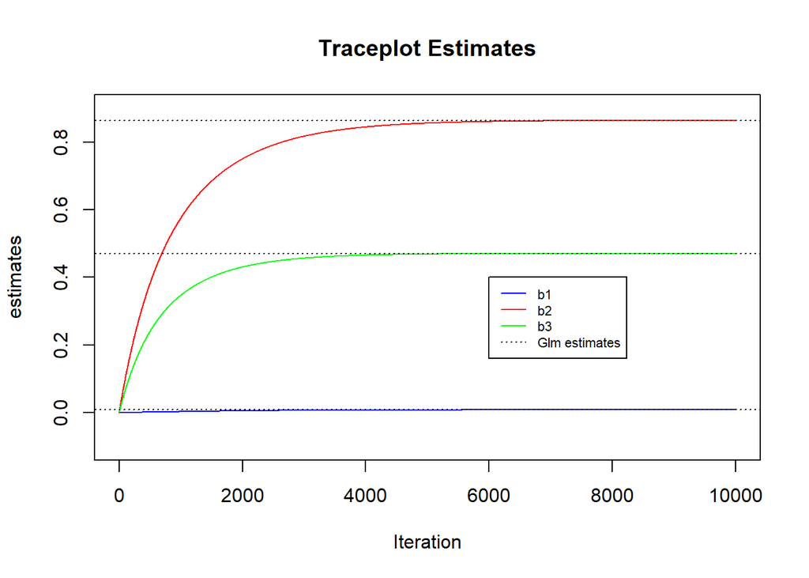

```r
plot(estimates[,1], col = 'blue', type = 'l', xlab = "Iteration", ylab = 'estimates', main = 'Traceplot Estimates',
     ylim = -0.1:0.9)
lines(estimates[,2], col = 'red', type = 'l')
lines(estimates[,3], col = 'green', type = 'l')

for(i in 1:3){
  abline(h = glmest[i], lty = 3, col = 'black')
}


legend(6000, 0.4, legend=c(sprintf("b%d", 1:3), 'Glm estimates'),
       col=c("blue", "red", "green", "black"), lty=c(1,1,1,3), cex=0.7)
```